# lab

**Convex and Distributed Optimization Lab**  
**MSIAM — Université Grenoble Alpes — 2018/2019**  
**Lecturers: Jérôme Malick, Yassine Laguel, Sélim Chraibi**

**Author: Benjamin Hérault**

```python
# Automatic reload of local libraries
%load_ext autoreload
%autoreload 2
%reload_ext autoreload
%matplotlib inline
```

> **I. Introduction**  
> **II. The optimization problem**  
> **III. Implementing the solvers**  
> GD (Gradient descent))  
> SGD (Stochastic Gradient Descent))  
> SAGA (Stochastic Average Gradient "Amélioré"))  
> SVRG (Stochastic Variance Reduced Gradient))  
> Comparison  
> **IV. Regularization**  
> **V. Further development**

In this lab, you will implement optimization algorithms that you've studied in class and use them to fit a logistic regression classification model.

You will be implementing a simplified version of [`sklearn.linear_model.LogisticRegression`](https://scikit-learn.org/stable/modules/generated/sklearn.linear_model.LogisticRegression.html).

Part of the work has already been done for you (see the `\lib` folder), so you'll only have to implement the `##### TODO (i) #####` sections of the code. Whenever you complete such a section, we ask you to **copy it in this notebook**. We want you to **only send us a pdf or html export of this notebook** so we won't be able to see your work if it's not in this notebook.

Report in groups of 1 to 3 students.  
**Due date:** Monday, January 6, 2019 (before midnight).  
**Send to:** cdo.grenoble@gmail.com

# I. Introduction

We consider the [Student Performance](http://archive.ics.uci.edu/ml/datasets/Student+Performance) dataset. This dataset contains student demographic, social, school-related features, how many classes they've missed, etc.

The goal we give ourselves is to predict whether a student will pass (final grade > 12).

We denote $A \in \mathcal{M}_{n,d}(\mathbb{R})$ the feature matrix, containing $n$ samples with $d$ features, and $b \in \{-1,1\}^n$ the label vector where $-1$ encodes `fail` and $1$ encodes `pass`.

The data has already been preprocessed (yay less work for you 🎉). You can check `\lib\datasets.py` if you're curious, otherwise, you can just use the following to load your dataset:

```python
from lib.datasets import load_student_data
print(load_student_data('data/student-mat.csv', split=0.25))
A_train, A_test, b_train, b_test = load_student_data('data/student-mat.csv', split=0.25)
```

[output not shown]

As mentioned previously, you're going to implement a simplified version of [`sklearn.linear_model.LogisticRegression`](https://scikit-learn.org/stable/modules/generated/sklearn.linear_model.LogisticRegression.html). So let's first see what the finished product should look like.

**Question:**

- Import [sklearn.linear_model.LogisticRegression](https://scikit-learn.org/stable/modules/generated/sklearn.linear_model.LogisticRegression.html) .
- Create an instance of sklearn's logistic regression classifiers with SAGA as its solver.
- Fit the classifier on the training data and compute the score of the fitted model on the test set.

```python
import sklearn as sk
from sklearn.linear_model import LogisticRegression
clf = LogisticRegression(solver='saga', max_iter=50*len(b_train))
clf.fit(A_train, b_train)
score = clf.score(A_test, b_test)
print(score)
```

```
0.9393939393939394
```

# II. The optimization problem

Logistic regression consists in finding the parameter $x \in \mathbb{R}^d$ that best fits: $$ b_i = \begin{cases} \phantom{-}1 \ \textrm{ if }\ \langle a_{i}, x\rangle \ge 0 \\ -1 \ \textrm{ if }\ \langle a_{i}, x\rangle < 0 \end{cases} $$ for all the samples $i$ of the training set (where $a_i$ is the $i^{th}$ line of $A$ and $b_i$ the $i^{th}$ element of $b$). To measure this fit, logistic regression chooses the following loss:

$$ \textrm{LogisticLoss}(b_i, \left\langle a_{i}, x\right\rangle ) = \log \left(1+\exp \left(-b_{i}\left\langle a_{i}, x\right\rangle\right)\right) $$

The corresponding optimization problem we will consider is the following:

Minimization of the empirical risk $f$ of the $L_2$-regularized logistic regression model, on the dataset $(A_{\textrm{train}},b_{\textrm{train}})$: $$ \begin{aligned} \textrm{min}_{x\in \mathbb{R}^d} \ f(x) \ &= \ \textrm{min}_{x\in \mathbb{R}^d} \ \frac{1}{n_{\textrm{train}}} \sum_{i=1}^{n_{\textrm{train}}} f_i(x) \\ &= \ \textrm{min}_{x\in \mathbb{R}^d}\frac{1}{n_{\textrm{train}}} \sum_{i=1}^{n_{\textrm{train}}} \textrm{LogisticLoss}(b_i, \left\langle a_{i}, x\right\rangle ) + \frac{l_2}{2}\|x\|^{2}_2, \end{aligned} $$ where $l_2 \ge 0$ is the $L_2$ regularization coefficient.

To simplify the notation, we'll stop indexing $A$, $b$ and $n$ with "$\textrm{train}$" in the following.

**Question:** $f$ is $\mu$-strongly convex.

- Give a lower bound on $\mu$.
- Complete **TODO (1)** in **\lib\linear_model.py**.

> **Answer:**

> $\forall k \in \{1,...n\}$

> > $\frac{\partial \textrm{LogisticLoss}(b_k, \left\langle a_{k}, x\right\rangle)}{\partial x_i} = \frac{-b_k.a_k^i \textrm{exp}(-b_k \langle a_k, x \rangle)} {1+ \textrm{exp}(-b_k \langle a_k, x \rangle)}$

> > $\frac{\partial^2 \textrm{LogisticLoss}(b_k, \left\langle a_{k}, x\right\rangle)}{\partial x_i \partial x_j} = \frac{a_k^i.a_k^j \textrm{exp}(-b_k \langle a_k, x \rangle)} {\left( 1+ \textrm{exp}(-b_k \langle a_k, x \rangle) \right)^2} \ge 0$

> > $x \mapsto \textrm{LogisticLoss}(b_k, \left\langle a_{k}, x\right\rangle)$ is convex

> And $x\mapsto l_2\|x\|^2_2$ is $l_2$-strongly convex.

> So $f$ is $l_2$-strongly convex, and $\mu \ge l_2$.

**Question:** Denote $\lambda_{\max}$ the largest eigenvalue of the real symmetric matrix $AA^T$.

- Prove that $\lambda_{\max}(\nabla^2 f_i) \le \lambda_{\max}(\frac{a_i a_i^T}{4} + l_2 I_d)$
- Prove that $\lambda_{\max}(a_i a_i^T) \le \|a_i\|^2_2$

A consequence of these results is that the $f_i$s and $f$ are all $L$-smooth with $L \le \frac{\max_i\|a_i\|^2_2}{4} + l_2$ and we can therefore use the following value in our implementation:

```
L = 0.25 * max(np.linalg.norm(A,2,axis=1))**2 + self.l2
```

# III. Implementing the solvers

To implement gradient methods, we need an oracle that will compute both batch gradients $\nabla f$ and partial gradients $\nabla f_i$.

**Question:** In the code below, $\nabla f$ has already been implemented.

- Complete **TODO (2)** bellow.
- Add your code to **\lib\linear_model.py**.

```python
def grad(x, i=None):
    '''
    Gradient of the objective function at x.
    If no i is given, grad should return the batch gradient.
    Otherwise, it should return the partial gradient associated the the datapoint (A[i], b[i]).
    '''

    if i is None: # return batch gradient
        output = -b/(1 + np.exp(b*np.dot(A, x)))
        output = sum(np.diag(output)).dot(A)/n
        output += self.l2*x
    else: # return partial gradient associated the datapoint (A[i], b[i])
        output = -b[i]/(1 + np.exp(b[i]*(np.dot(A[i], x))))
        output = output* A[i]
        output += self.l2 * x

    return output
```

# GD (Gradient descent)

At iteration k of the GD algorithm, the following update is executed:

$$ x_{k+1} \leftarrow x_{k} - \gamma\nabla f(x_k) $$

**Question:**

- What stepsize $\gamma$ ensures the convergence of this algorithm and under what assumptions?
- Complete **TODO (3)** and **TODO (4)**
- Add your code to **\lib\solvers.py**.

> **Answer:** We need $f$ to be convex, differentiable L-liptzitch and $\gamma \in ]0, \frac{2}{L}[$

**Question:** Run the code below to test your code.

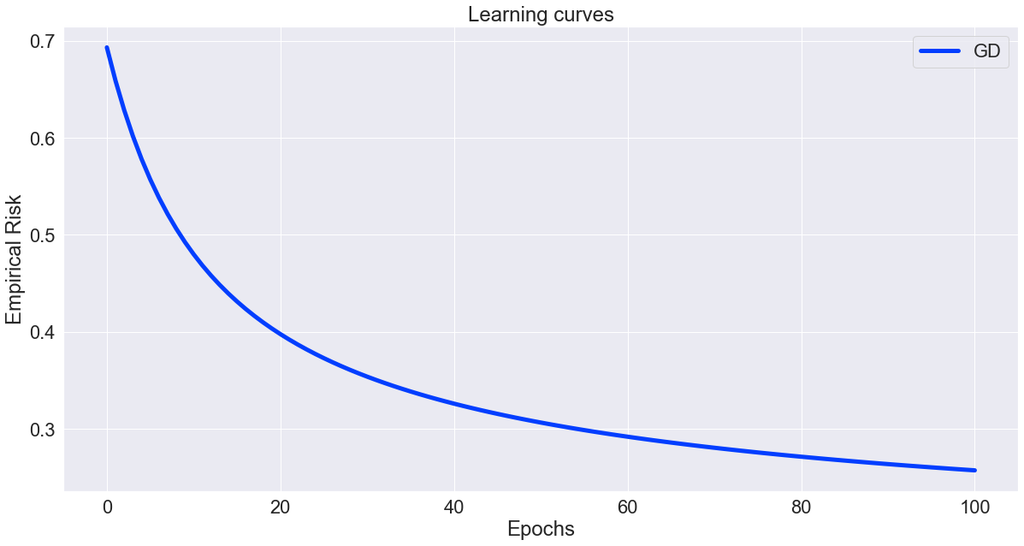

```python
from lib.linear_model import LogisticRegression
from lib.visuals import learning_curve

clf_gd = LogisticRegression(solver='gd', l2=0.01, max_iter=100)
clf_gd.fit(A_train, b_train)

learning_curve(GD=clf_gd)
```

```python
def GD(x0, grad, max_iter, n, L, mu):
    '''
    Parameters
    ----------
    x0: array, shape (nb_features,)
        Initialisation of the solver
    grad: function
        Gradient of the objective function
    max_iter: int
        Number of iterations (i.e. number of descent steps). Note that for GD or SVRG,
        one iteration is one epoch i.e, one pass through the data, while for SGD, SAG and SAGA,
        one iteration uses only one data point.
    n: int
        Dataset size
    L: float
        Smoothness constant of the objective function
    mu: float
        Strong convexity constant of the objective function

    Returns
    -------
    x: array, shape (nb_features,)
        final iterate of the solver
    x_tab: array, shape (nb_features, max_iter)
        table of all the iterates
    '''
    stepsize  = 2/L - 0.001  #We want to maximize the stepsize, but still be under 2/L, we choose 0.001 of tolerance
    x         = x0
    x_tab     = np.copy(x)

    for k in range(max_iter):
        x     = x - stepsize*grad(x)
        x_tab = np.vstack((x_tab, x))

    return x, x_tab
```

# SGD (Stochastic Gradient Descent)

At iteration k of the SGD algorithm, the following update is executed:

$$ \begin{cases} i \textrm{ chosen randomly in } \{1...n\}\\ x_{k+1} \leftarrow x_{k} - \gamma_k \nabla f_i(x_k) \\ \end{cases} $$

**Question:**

- What stepsize $\gamma_k$ ensures the convergence of this algorithm and under what assumptions?
- Complete **TODO (5)**
- Add your code to **\lib\solvers.py**.

```python
def SGD(x0, grad, prox, max_iter, n, L, mu):
    x = x0
    x_tab = np.copy(x)

    for k in range(max_iter):
        stepsize = 0.1*np.log(k+2)**2/(k+1.0)
        i = random.randint(0,n-1)
        x = prox(x - stepsize*grad(x, i))

        if k%n == 0: # each completed epoch
            x_tab = np.vstack((x_tab, x))

    return x, x_tab
```

**Question:** Run the code below to test your code.

**Question:**

- What stepsize $\gamma_k$ ensures the convergence of this algorithm and under what assumptions?
- Complete **TODO (6)**
- Add your code to **\lib\solvers.py**.

> **Answer:** The step size for the SGD algorithm should verify $\sum_{k=0}^\infty \gamma_k \rightarrow \infty$ and $\sum_{k=0}^\infty \gamma_k^2 \lt \infty$. A common way is to use $\gamma_k = \frac{1}{k+1}$, we will use $\gamma_k = \frac{(\operatorname{ln}(k+2)^2}{k+1}$ for faster convergence. For stability we multiply this factor by $0.1$ to give give a more stable behavior.

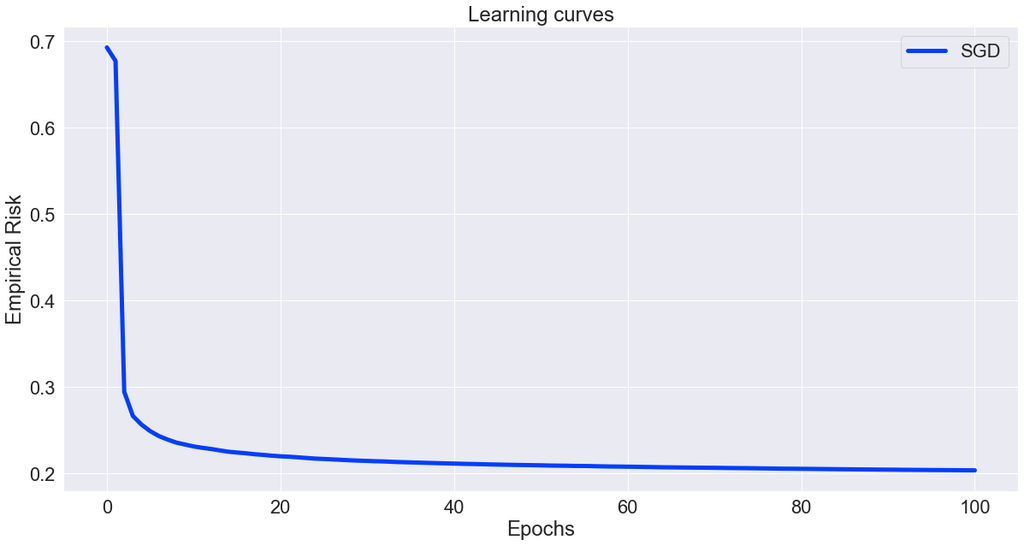

```python
clf_sgd = LogisticRegression(solver='sgd', l2=0.01, max_iter=100*len(b_train))
clf_sgd.fit(A_train, b_train)

learning_curve(SGD=clf_sgd)
```

# SAGA (Stochastic Average Gradient "Amélioré")

SAGA starts by computing a single batch gradient, then at iteration k, the following update is executed:

$$ \begin{cases} i \textrm{ chosen randomly in } \{1...n\}\\ x_{k+1} \leftarrow x_{k} - \gamma_k\big(\nabla f_i(x_k) - \alpha_i + \bar{\alpha}\big) \\ \alpha_i \leftarrow \nabla f_i(x) \end{cases} $$

where $(\alpha_j)_{j=1}^n$ are gradients evaluated at previous iterates and $\bar{\alpha}=\frac{1}{n}\sum^n_{j=1}\alpha_j$.

> **Answer:** If f is L-lipzitch, strongly convex then the SAGA converge with stepsize $\frac{1}{2(\mu n + L)}$ [1]

> In the non strongly convex case, a recommended stepsize is $\frac{1}{3L}$ [1]

> source : [1] SAGA: A Fast Incremental Gradient Method With Support for Non-Strongly Convex Composite Objectives (Aaron Defazio Francis Bach Simon Lacoste-Julien) https://arxiv.org/pdf/1407.0202.pdf

```python
def SAGA(x0, grad, max_iter, n, L, mu):
    x = x0
    x_tab = np.copy(x)
    stepsize = 1.0/(2*(mu*n+L))
    tab = np.array([grad(x0, i) for i in range(n)])
    for k in range(max_iter):
        i = random.randint(0,n-1)
        g = grad(x,i)
        x = x - stepsize * (g - tab[i] + sum(tab)/n)
        tab[i] = grad(x,i)

        if k%n == 0: # each completed epoch
            x_tab = np.vstack((x_tab, x))

    return x, x_tab
```

**Question:** Run the code below to test your code.

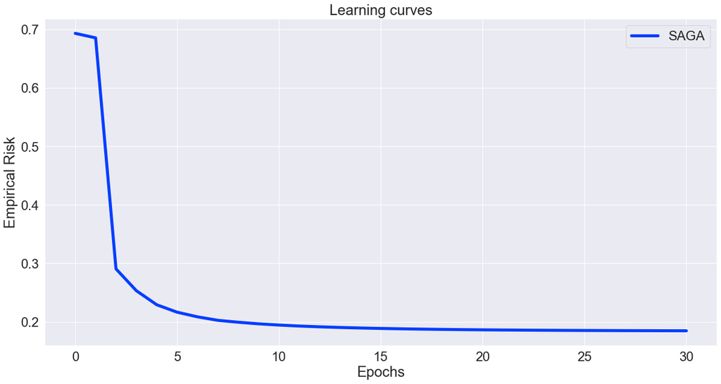

```python
clf_saga = LogisticRegression(solver='saga', l2=0.01, max_iter=30*len(b_train))
clf_saga.fit(A_train, b_train)

learning_curve(SAGA=clf_saga)
```

# SVRG (Stochastic Variance Reduced Gradient)

At iteration k of the SVRG algorithm, we perform the following:

$$ \begin{cases} \textrm{Compute the batch gradient } \nabla f(x_k)\\ \textrm{Initialise }y_0 = x_k\\ \textrm{for m in 0...M-1: } \begin{cases} i \textrm{ chosen randomly in } \{1...n\} \\ y_{m+1} \leftarrow y_{m} - \gamma_k\big(\nabla f_i(y_m) - \nabla f_i(x_k) + \nabla f(x_k)) \end{cases}\\ x_{k+1} \leftarrow y_{M} \end{cases} $$

**Question:**

- What stepsize $\gamma_k$ ensures the convergence of this algorithm and under what assumptions?
- Complete **TODO (7)**
- Add your code to **\lib\solvers.py**.

```python
def SVRG(x0, grad, max_iter, n, L, mu):
    x = x0
    x_tab = np.copy(x)
    stepsize = 1.0/(2.1*L)
    for k in range(max_iter):
        grad_batch = grad(x)
        y=x
        M=n
        for m in range(M):
            i = random.randint(0,n-1)
            y = prox(y- stepsize*(grad(y,i) - grad(x,i) + grad_batch))
        x=y
        x_tab = np.vstack((x_tab, x))

    return x, x_tab
```

> **Answer:** Unlike SGD, the learning rate for SVRG does not have to decay, which leads to faster convergence as one can use a constant learning rate: $\gamma \in ] 0, \frac{1}{2L}[$ [2].

> source: Accelerating Stochastic Gradient Descent using Predictive Variance Reduction (Rie Johnson, Tong Zhang) https://papers.nips.cc/paper/4937-accelerating-stochastic-gradient-descent-using-predictive-variance-reduction.pdf

**Question:** Run the code below to test your code.

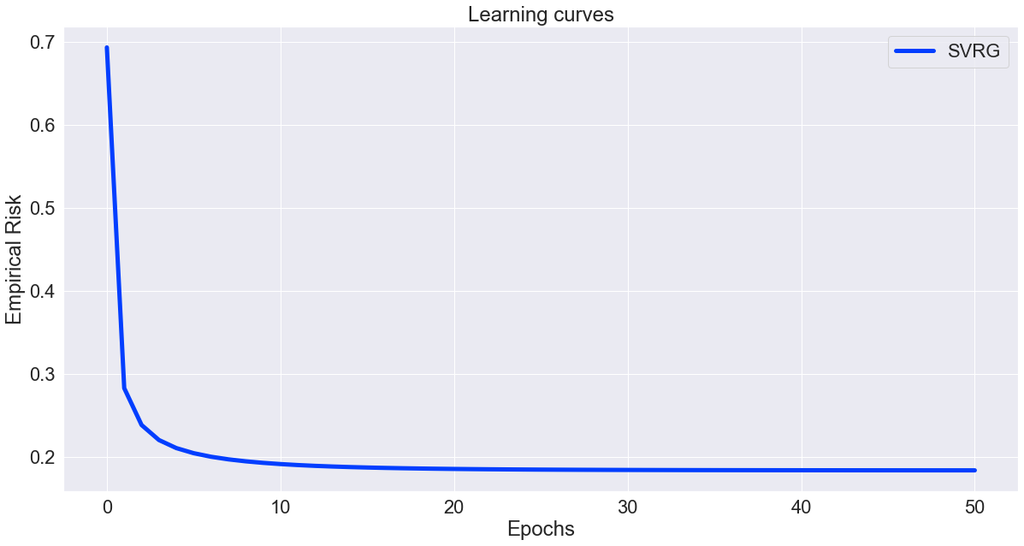

```python
clf_svrg = LogisticRegression(solver='svrg', l2=0.01, max_iter=50)
clf_svrg.fit(A_train, b_train)

learning_curve(SVRG=clf_svrg)
```

# Comparison

**Question:** Run the code below to compare all the methods you've implemented.

```python
epochs = 50
n = len(b_train)

clf_gd   = LogisticRegression(solver='gd', l2=0.01, max_iter=epochs)
clf_sgd  = LogisticRegression(solver='sgd', l2=0.01, max_iter=epochs*n)
clf_saga = LogisticRegression(solver='saga', l2=0.01, max_iter=epochs*n)
clf_svrg = LogisticRegression(solver='svrg', l2=0.01, max_iter=epochs)

clf_gd.fit(A_train, b_train)
clf_sgd.fit(A_train, b_train)
clf_saga.fit(A_train, b_train)
clf_svrg.fit(A_train, b_train)
```

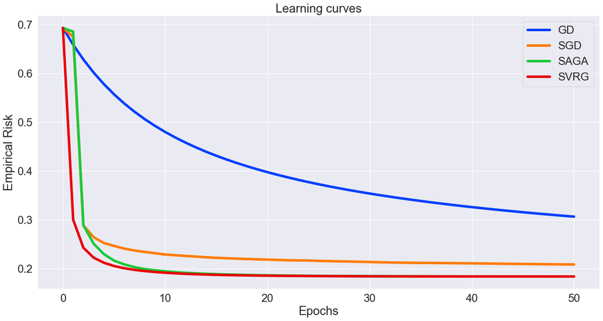

```
gd:	Accuracy on training set: 89.5%
	Accuracy on testing set:  88.9%
sgd:	Accuracy on training set: 93.9%
	Accuracy on testing set:  93.9%
saga:	Accuracy on training set: 95.3%
	Accuracy on testing set:  93.9%
svrg:	Accuracy on training set: 95.3%
	Accuracy on testing set:  93.9%
```

```python
learning_curve(GD=clf_gd, SGD=clf_sgd, SAGA=clf_saga, SVRG=clf_svrg)

for clf, name in zip([clf_gd, clf_sgd, clf_saga, clf_svrg], ['gd', 'sgd', 'saga', 'svrg']):
    print(name + ':' \
          + "\tAccuracy on training set: {0:0.1f}%".format(100*clf.score(A_train, b_train)))
    print("\tAccuracy on testing set:  {0:0.1f}%".format(100*clf.score(A_test, b_test)))
```

All the curves above should converge to the minimum. The best convergence speed is obtain with SAGA and SVRG, they have almost the same behavior, but the SVRG is a little bit faster. It is probably because it is less sensitive to initialisation than the SAGA. Indeed, the first batch of the saga does not decrease much the empirical risk.

We notice that the standard gradient descent is far slower than any other method and this result confirm that we should in practice use more advanced technics.

# IV. Regularization

**Question:**

- Rewrite the empirical risk minimization objective with both $L_1$ and $L_2$ regularization (with coefficients $l_1$ and $l_2$).
- Is this objective $\mu$-strongly convex, $L$-smooth, differentiable?
- Complete the **TODO (8)** to account for the new term in the objective.
- Add your code to **lib/linear_model.py**.

> **Answer:**

> > i) Here is the empirical risk minimization objective with both $L_1$ and $L_2$ regularizations: $$ \begin{aligned} \textrm{min}_{x\in \mathbb{R}^d} \ f(x) &= \ \textrm{min}_{x\in \mathbb{R}^d}\frac{1}{n_{\textrm{train}}} \sum_{i=1}^{n_{\textrm{train}}} \textrm{LogisticLoss}(b_i, \left\langle a_{i}, x\right\rangle ) + \frac{l_2}{2}\|x\|^{2}_2 + l_1\|x\|_1, \end{aligned} $$

> > ii) $\|.\|_1$ is convex, so the objective function is $\mu$-strongly convex.

> > $\|.\|_1$ is differentiable almost everywhere, so is the objective function.

> > $\|.\|_1$ is not differentiable everywhere so the the objective function is not L-smooth.

```
self._empirical_risk = lambda x: sum(self._logistic_loss(A, b, x))/n \
                                 + self.l2/2.0 * np.linalg.norm(x,2)
                                 + self.l1*np.linalg.norm(x,1)
```

The minimization algorithms we've implemented have a slow rate of convergence for this new objective function. We will therefore use *proximal* variations of these algorithms.

**Question:** Using the $\textrm{prox}_{l_1 \|\cdot\|_1}$ operator, write down the $k^{th}$ step of proximal GD, proximal SGD, proximal SAGA, and proximal SVRG.

> **Answer:** reminder:

> GD : $$x_{k+1} \leftarrow \operatorname{prox}_{l_1\|.\|_1}(x_k - \gamma \nabla f(x_k))$$

> SGD : $$ \begin{cases} i \textrm{ chosen randomly in } \{1...n\}\\ x_{k+1} \leftarrow \operatorname{prox}_{l_1\|.\|_1}(x_k - \gamma_k \nabla f_i(x_k))\\ \end{cases} $$

> SAGA:$$ \begin{cases} i \textrm{ chosen randomly in } \{1...n\}\\ x_{k+1} \leftarrow \operatorname{prox}_{l_1\|.\|_1}(x_{k} - \gamma_k\big(\nabla f_i(x_k) - \alpha_i + \bar{\alpha}\big))\\ \alpha_i \leftarrow \nabla f_i(x) \end{cases} $$

> SVRG : $$ \begin{cases} \textrm{Compute the batch gradient } \nabla f(x_k)\\ \textrm{Initialise }y_0 = x_k\\ \textrm{for m in 0...M-1: } \begin{cases} i \textrm{ chosen randomly in } \{1...n\} \\ y_{m+1} \leftarrow \operatorname{prox}_{l_1\|.\|_1}(y_{m} - \gamma_k\big(\nabla f_i(y_m) - \nabla f_i(x_k) + \nabla f(x_k))) \end{cases}\\ x_{k+1} \leftarrow y_{M} \end{cases} $$

**Question:**

- Give a closed-form expression of $\textrm{prox}_{l_1 \|\cdot\|_1}$
- Complete **TODO (9)** (note that you can access the $l_1$ coefficient using **self.l1**).
- Add your code to **\lib\linear_model.py**.

> **Answer:**

> i) $$ \operatorname{prox}_{l_1\|.\|_1}(v) := \operatorname{argmin}_{x\in \mathbb{R}^d} \left\{l_1\|x\|_1 + \frac{1}{2}\|x-v\|_2^2 \right\}$$ Then for any $v\in \mathbb{R}^d$ $$ v = \operatorname{argmin}_{x\in \mathbb{R}^d} \left\{l_1\|x\|_1 + \frac{1}{2}\|x-v\|_2^2 \right\}\\ \Leftrightarrow \forall i \in \{1...d\}, v_i = \operatorname{argmin}_{x\in \mathbb{R}} \left\{|x| + \frac{1}{2}|x-v_i|^2 \right\}\\ \Leftrightarrow v_i = \operatorname{sign}(v_i)\operatorname{max}(|v_i| - l_1, 0)$$ Finally, we have $$ \operatorname{prox}_{l_1\|.\|_1}(v) = \left[ \operatorname{sign}(v_i)\operatorname{max}(|v_i| - l_1, 0) \right] _{1\le i\le d}\\ $$

```python
def prox(x, stepsize):
    return np.array([np.sign(xi)*max((np.abs(xi)-self.l1, 0)) for xi in x])
```

**Question:**

- Add **prox** to the attributes of the solvers (both in the call to **self.solver** in **/lib/linear_model.py** and in **/lib/solvers.py**) as follows:  
  solver(x0, grad, **prox**, self.max_iter, n, L, mu)
- Add a proximal step to all the algorithms in **/lib/solvers.py**.
- Paste one of these algorithms in the cell bellow.

```python
# def {GD or SGD or SAGA or SVRG}(x0, grad, prox, max_iter, n, L, mu):


def SGD(x0, grad, prox, max_iter, n, L, mu):
    x = x0
    x_tab = np.copy(x)

    for k in range(max_iter):
        stepsize = 0.1*np.log(k+2)**2/(k+1.0)
        i = random.randint(0,n-1)
        x = prox(x - stepsize*grad(x, i))

        if k%n == 0: # each completed epoch
            x_tab = np.vstack((x_tab, x))

    return x, x_tab
```

**Question:** If your proximal gradient descent is correctly implemented, the following cell will plot the support of the solution for various values of $l_1$.

- Interpret the plot and explain what can $L_1$ regularization be used for.

> **Answer:** In this plot, the absissa axis represents the value of $l_1$, and the ordinate axis indecate the index of the cordinates. This plot shows, for different value of l1, the coordinates where the coeficient is non zero (indicated by a dot) after the logistic regression. We notice that the bigger is $l_1$ coefficient, the more sparse is the vector and the larger is the number of coefficients set to zero. This can be useful to eliminate features that are not relevant for the given prediction.

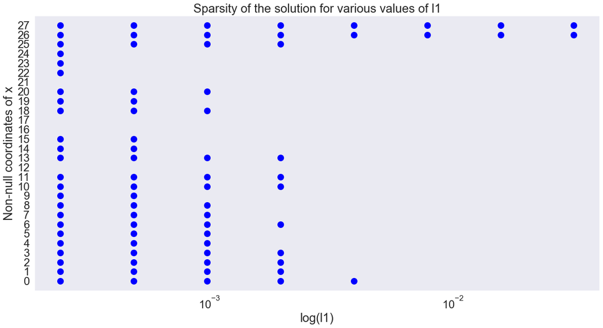

```python
from lib.visuals import l1_regularization_plot

clf = lambda l1: LogisticRegression(solver='gd', l1=l1, l2=0.1, max_iter=1000)

l1_regularization_plot(clf, A_train, b_train)
```

**Question:** The following cell will plot the value of the coordinates of the solution for various values of $l_2$.

- Interpret the plot and explain what can $L_2$ regularization be used for.

> **Answer:** In this plot, the absissa axis represents the value of l2, and the ordinate axis indecate the value of a given cordinate. This plot shows, for different value of l2, the value of each coordinate after the logistic regression. We notice that the higher is the $l_2$ coeficient, the lower are the values of each coordinates. Actually, this regularization is often used because it leads more stability and avoid overfitting.

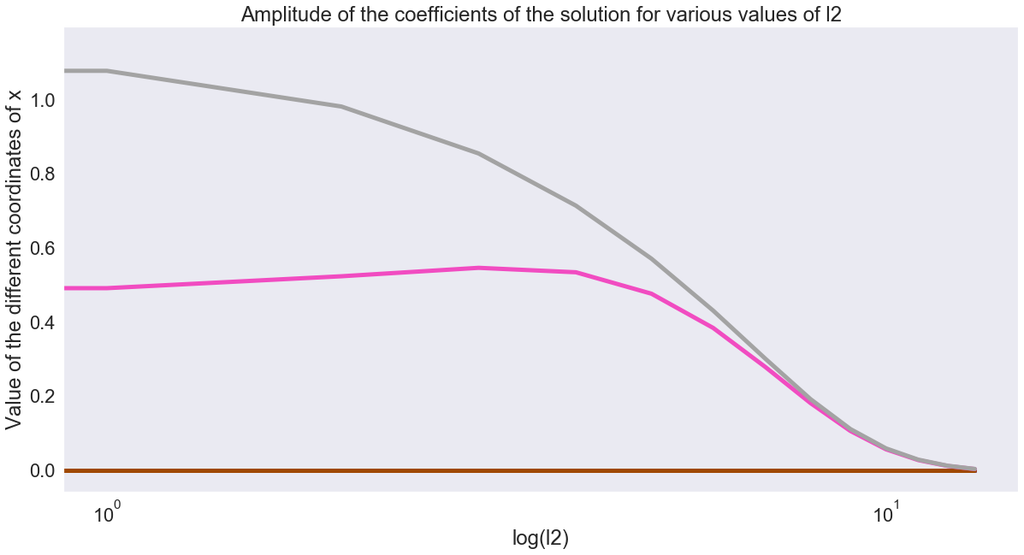

```python
from lib.visuals import l2_regularization_plot

clf = lambda l2: LogisticRegression(solver='gd', l1=0.01, l2=l2, max_iter=1000)

l2_regularization_plot(clf, A_train, b_train)
```

# V. Further development

We expect that you go beyond the lab's questions and that you develop certain aspects of your work, depending on your personal interests and skills, for instance:

- Implementations and numerical tests (further developments, more experiments, etc.)
- Applications in learning or statistics (interpretation of some results, other models, other datasets, etc.)
- Theoretical or mathematical questions (convergence proofs, convergence rates, advanced versions of an algorithm, theoretical analysis of special cases, etc.)

**Keyword ideas**: standard or stochastic Newton method, ADMM, continuation methods, tests on large scale datasets, intuition behind variance reduction, catalyst...

# Answer

## I) Optimal tuning of $l_1$ and $l_2$ parameters

We have seen, in the previous section that it can be interesting to use $L_1$ and $L_2$ regularizations. A first idea would be: from an initialised value $(l_1^0, l_2^0)$ we repeat the following untill convergence:

$$ \begin{cases} \textrm{Compute the score on the test set for a range of value for }l_1\textrm{, with }l_2\textrm{ fixed.}\\ \textrm{Select the value for }l_1\textrm{ where the score is maximum.}\\ \textrm{Compute the score on the test set for a range of value for }l_2\textrm{, with }l_1\textrm{ fixed.}\\ \textrm{Select the value for }l_2\textrm{ where the score is maximum.} \end{cases} $$

Here are plotted the values of the score for various value of $l_1$ and $l_2$. With this plot, we have, with $l_1=0.01$ fixed, the maximum score is obtain with $l_2=0.01$, on the other hand, when $l_2=0.01$ fixed, the maximum score is obtain with $l_1=0.01$ so we reached convergence of the above algorithm.

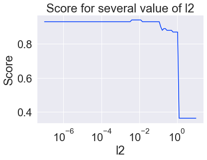

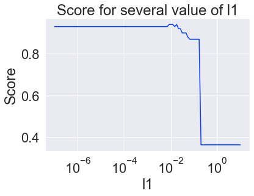

```python
import numpy as np
import matplotlib.pyplot as plt


def plot_empirical_risk(tab, clf_func, xlabel):
    res=[]
    for l2 in l2_tab:
        clf = clf_func(l2)
        clf.fit(A_train, b_train)
        res.append([l2, clf.score(A_test, b_test)])
    res = np.array(res).transpose()
    plt.xscale('log')
    plt.plot(res[0], res[1])
    plt.ylabel('Score')
    plt.xlabel(xlabel)
    plt.title('Score for several value of '+xlabel)
    plt.show()

clf_l2 = lambda l2: LogisticRegression(solver='bfgs', l1=0.01, l2=l2, max_iter=1000)
l2_tab = np.power(10.0, np.array(np.linspace(-7,1, 100)))

clf_l1 = lambda l1: LogisticRegression(solver='bfgs', l1=l1, l2=0.01, max_iter=1000)
l1_tab =np.power(10.0, np.array(np.linspace(-8,1, 100)))

plot_empirical_risk(l2_tab, clf_l2, "l2")
plot_empirical_risk(l1_tab, clf_l1, "l1")
```

One should combine this method with cross validation (not implemented here) to find good $l_1$ and $l_2$ parameters and avoid overfitting.

## A popular quasi-Newton method : BFSG

In another section, we try a very popular quasi-Newton method: BFGS. From an initial $x0$ and an approximate Hessian matrix $H_0$, BFGS algorithm converge to the solution by repeating the following:

> 1. $p_k \leftarrow -H^{-1}_k\nabla f(x_k)$
> 2. perform a linear search : $\alpha_k \leftarrow \underset{\alpha \in \mathbb{R}}{\operatorname{argmin}}f(x_k + \alpha p_k)$
> 3. $s_k \leftarrow \alpha_k p_k$, $x_{k+1} \leftarrow x_k+s_k$
> 4. $y_k \leftarrow \nabla f(x_{k+1}) - \nabla f(x_k)$
> 5. $H_{k+1} \leftarrow H_k +\frac{y_k^T y_k}{y_k^Ts_k} - \frac{H_k s_k s_k^T H_k}{s_k^T B_k s_k}$

We wrap the function _fmin*bfgs* of the scipy.optimize library in the solvers as follows:

```python
def BFGS(x0, grad, empirical_risk, max_iter):
    from scipy.optimize import fmin_bfgs

    return fmin_bfgs(empirical_risk, x0, grad, retall=True, maxiter=max_iter, gtol=1e-12, disp=0)
```

After a few modifications of the *LogisticRegression* class, we can plot this method among the others to compare the performance

```python
clf_bfgs = LogisticRegression(solver='bfgs', l2=0.01, max_iter=1000)
clf_bfgs.fit(A_train, b_train)
print(clf_bfgs.score(A_train, b_train))
print(clf_bfgs.score(A_test, b_test))
```

```
0.9358108108108109
0.9292929292929293
```

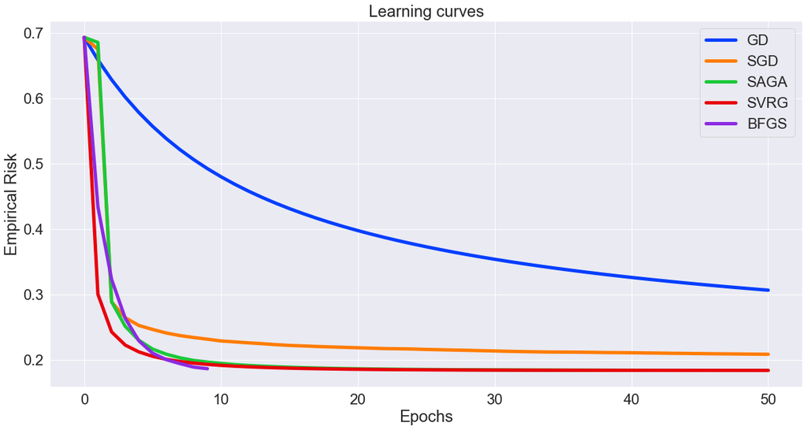

```python
learning_curve(GD=clf_gd, SGD=clf_sgd, SAGA=clf_saga, SVRG=clf_svrg, BFGS=clf_bfgs)
```

The overal behaviour of the BFGS method is similar to SVRG and SAGA for this dataset.